# CITESeQC Tutorial

Jie Sun

2024-01-11

## install package and library independency

[output not shown]

```
## Attaching SeuratObject
```

[output not shown]

## Read in data from the h5 file and create a Seurat object

```r
filePath <- "/Users/sunjie/Desktop/CiteSeq/CITESeQC/pbmc_10k_protein_v3_filtered_feature_bc_matrix.h5" # change to your own file path
pbmc <- readCITEseqData(filePath)
```

```
## Genome matrix has multiple modalities, returning a list of matrices for this genome
```

# RNA_read_corr()

## ‘RNA_read_corr()’ produces a scatterplot correlating the number of detected genes with the total number of molecules identified in the transcriptome.

## Since the cutoffs for good-quality cells will be passed as the arguments to the function, users can modify them for their data.

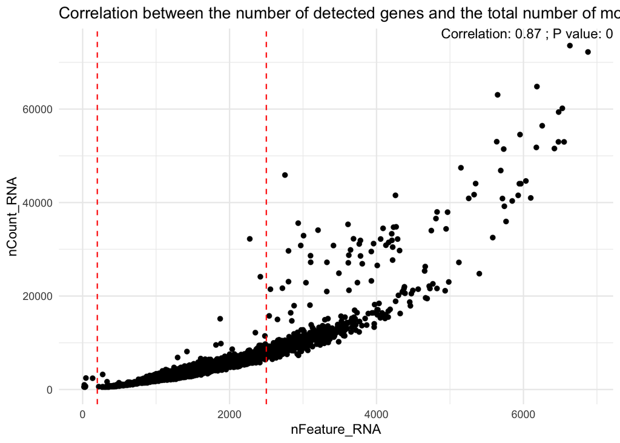

```r
RNA_read_corr(pbmc)
```

# ADT_read_corr()

## ‘ADT_read_corr()’ produces a scatterplot correlating the number of detected ADTs with the total number of ADT molecules identified on the cell surfaces.

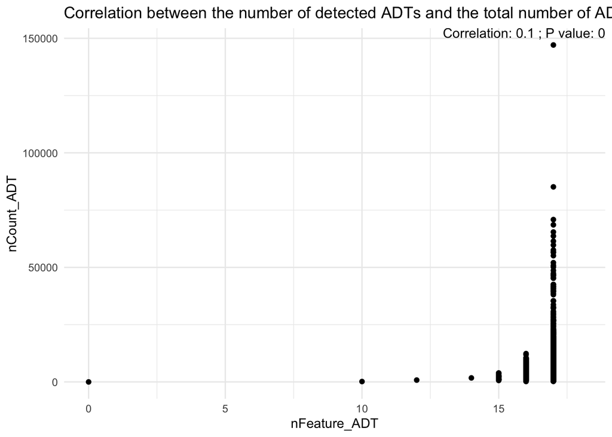

```r
ADT_read_corr(pbmc)
```

# RNA_mt_read_corr()

## With the correlation coefficient, users can test the hypothesis that the mitochondrial percentage should be constant regardless of the number of identified molecules.

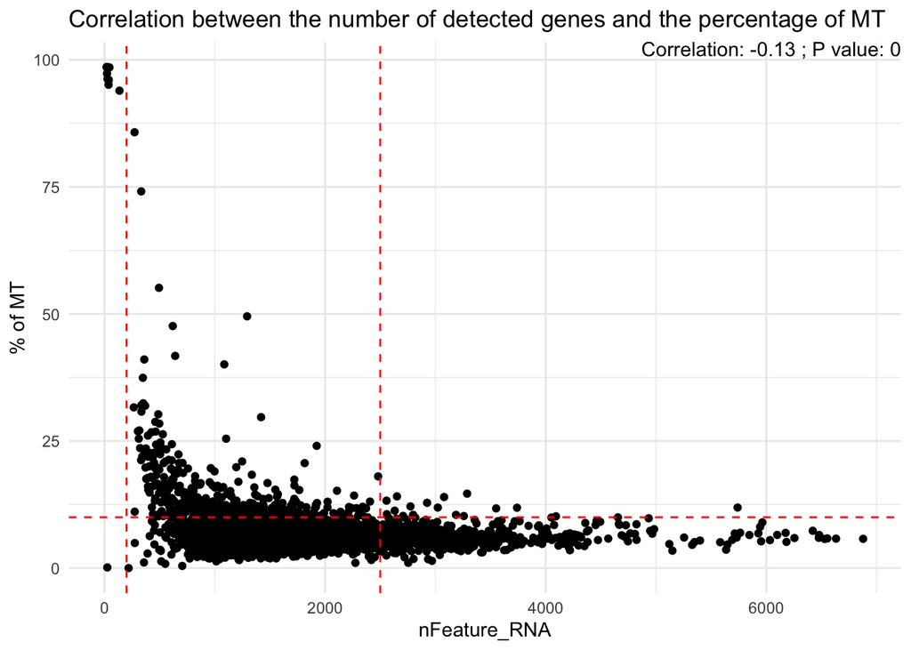

```r
RNA_mt_read_corr(pbmc)
```

## Filter cells based the cutoff as input by user. ## If you don’t want to filter out anything, just skip this step.

```r
pbmc.trim <- trimReads(pbmc)
```

# def_clust()

## ‘def_clust()’ either defines the cell clusters based on the input gene expression matrix or imports the definition.

# RNA_dist()

## ‘RNA_dist()’ visualizes the specificity of the input gene expression across the cell clusters defined or imported through def_clust().

## For quantification and comparison, it will calculate Shannon entropy on the expression distribution across the clusters.

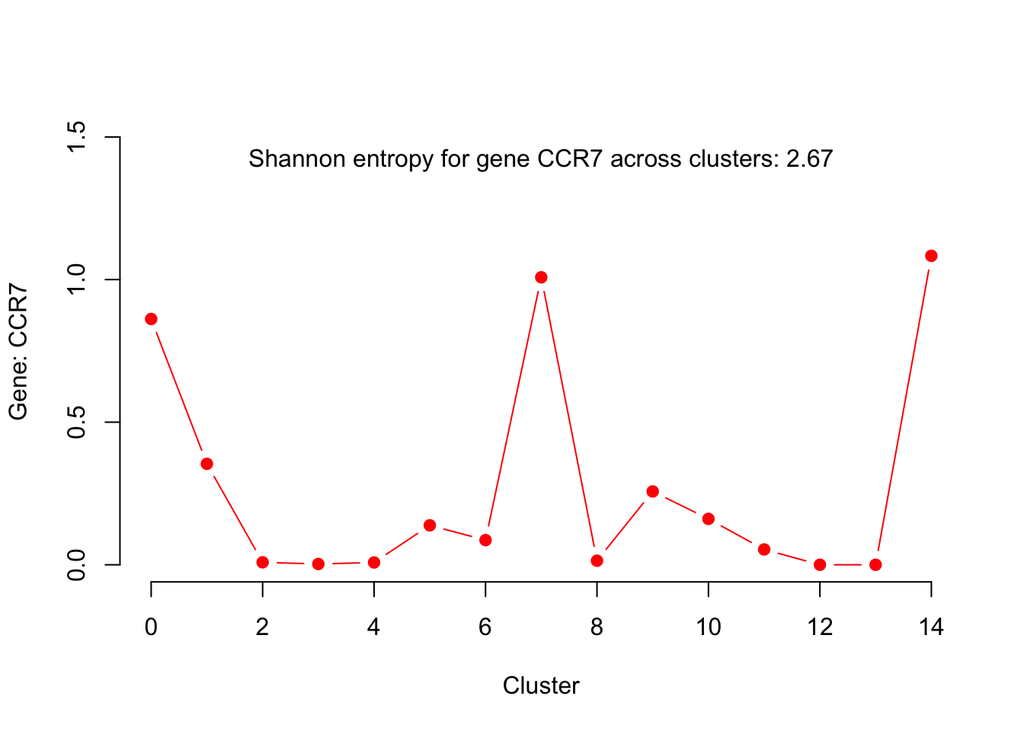

```r
RNA_dist(pbmc_clust$pbmc, "CCR7")
```

# multiRNA_hist()

## The histogram will plot how specific the marker genes are across the clusters. Users can modify the number of marker genes.

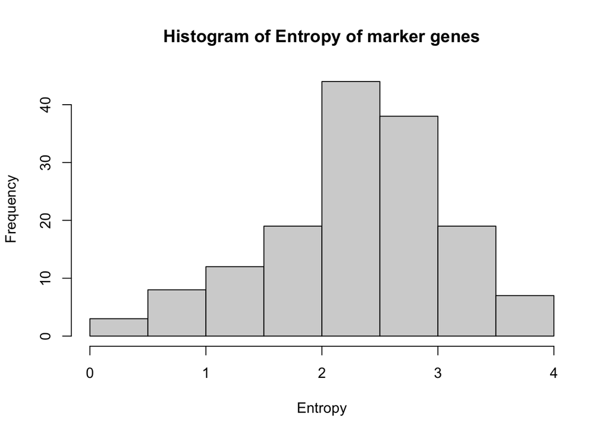

```r
multiRNA_hist(pbmc_clust$pbmc, pbmc_clust$markerListGEX)
```

# ADT_dist()

## ‘ADT_dist()’ visualizes the specificity of the input ADT abundance across the cell clusters. Specifically, it will calculate Shannon entropy on the expression distribution across the clusters.

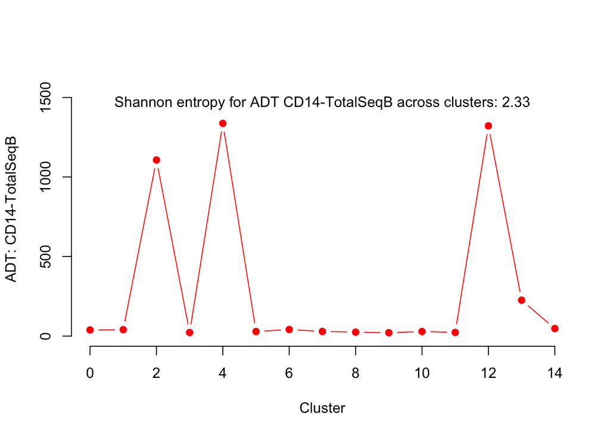

```r
ADT_dist(pbmc_clust$pbmc, "CD14-TotalSeqB")
```

# multiADT_hist()

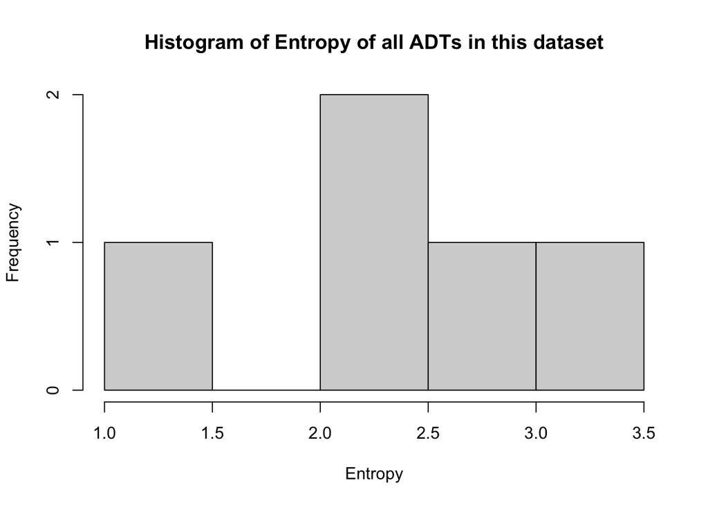

```r
ADTs <- c("CD14-TotalSeqB", "CD4-TotalSeqB", "TIGIT-TotalSeqB", "CD8a-TotalSeqB", "CD19-TotalSeqB")
multiADT_hist(pbmc_clust$pbmc, ADTs)
```

# RNA_ADT_read_corr()

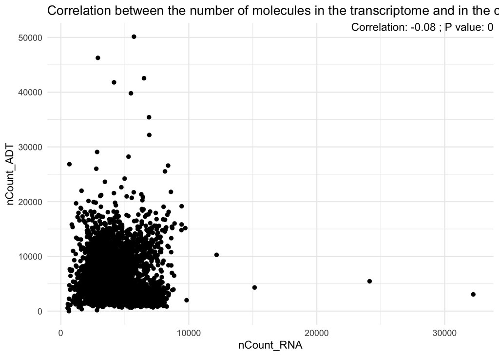

```r
RNA_ADT_read_corr(pbmc_clust$pbmc)
```

# RNA_ADT_UMAP_corr()

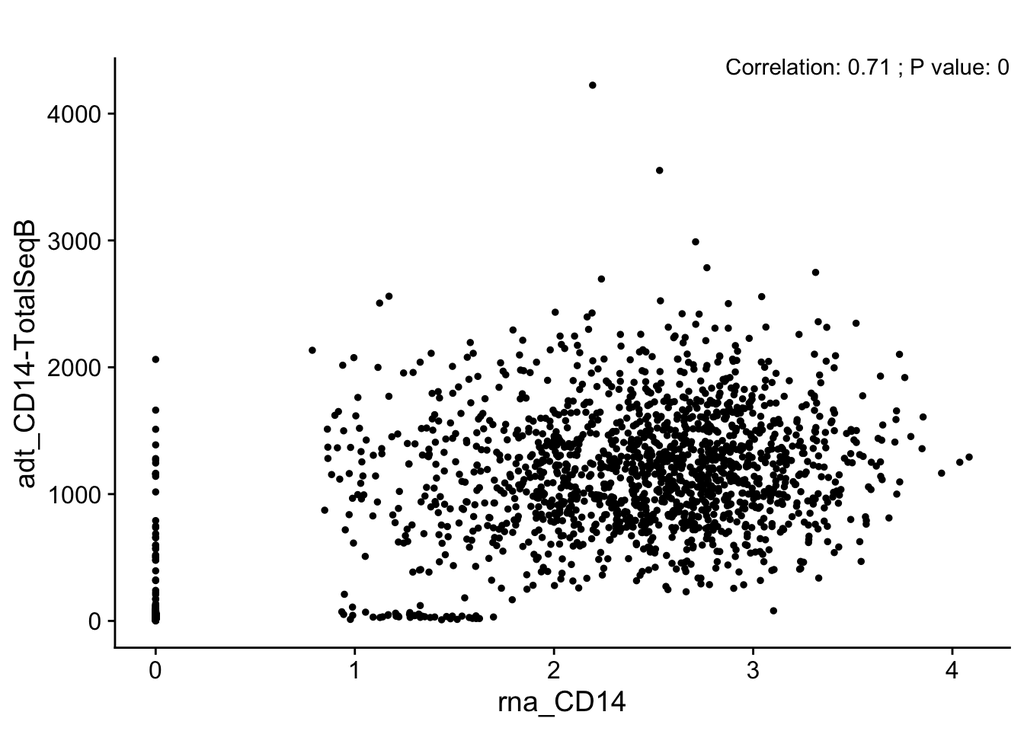

```r
RNA_ADT_UMAP_corr(pbmc_clust$pbmc, "rna_CD14", "adt_CD14-TotalSeqB")
```

# RNA_ADT_cluster_corr()

## ‘RNA_ADT_cluster_corr()’ is a set of scatterplots each drawn for each cell cluster, showing the correlation between the input ADT abundance and the corresponding gene expression for the cluster.

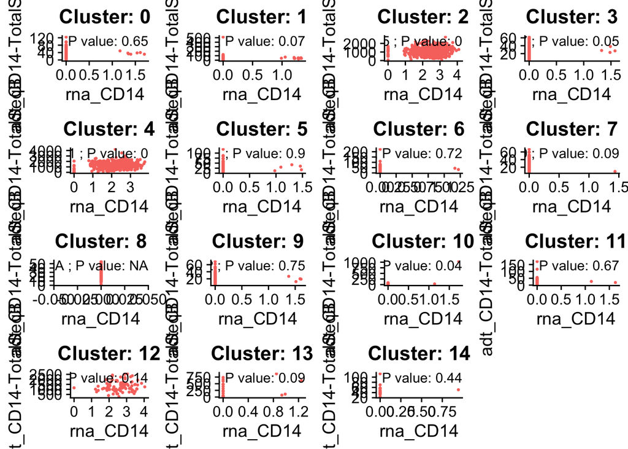

```r
RNA_ADT_cluster_corr(pbmc_clust$pbmc, "rna_CD14", "adt_CD14-TotalSeqB")
```

# RNA_ADT_hist()

## ‘RNA_ADT_hist()’ is a histogram of the correlation coefficients in all pairs of ADTs and the corresponding genes in expression.

## Function to create scatter plots and histograms for correlation coefficients.

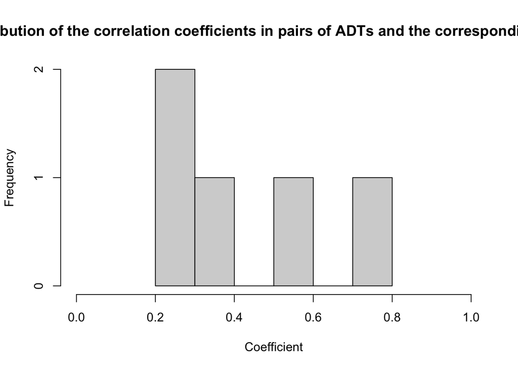

```r
RNA_features <- c('rna_CD14', 'rna_CD4', 'rna_TIGIT', 'rna_CD8A', 'rna_CD19')
ADT_features <- c('adt_CD14-TotalSeqB', 'adt_CD4-TotalSeqB', 'adt_TIGIT-TotalSeqB', 'adt_CD8a-TotalSeqB', 'adt_CD19-TotalSeqB')
RNA_ADT_hist(pbmc_clust$pbmc, RNA_features, ADT_features)
```

# RNA_ADT_cluster_hist()

## ‘RNA_ADT_cluster_hist()’ is a set of histograms, each showing the distribution of the correlation coefficients in all pairs of ADTs and the corresponding genes for each cell cluster.

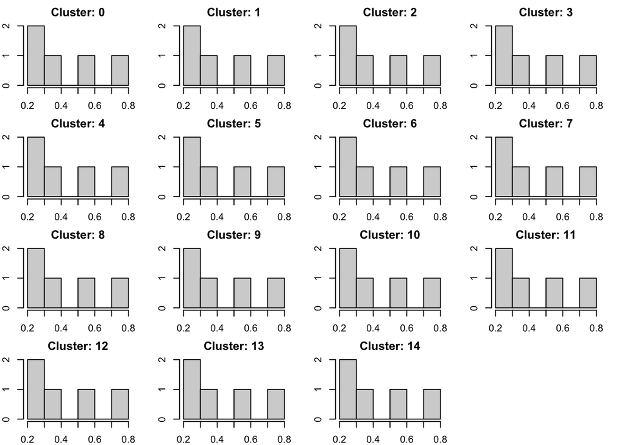

```r
RNA_ADT_cluster_hist(pbmc_clust$pbmc, RNA_features, ADT_features)
```